# Milestone Report

Diane Clow

11/27/2016

### Introduction

This is the first Milestone Report for the Data Scientist Specalization Capstone Project on Coursera. (https://www.coursera.org/specializations/jhu-data-science) This project involves working with text data to create a prediction algorithm that will predict the next word.

This report was written after the second weeks assignments and will give a general overview of the progress that I have made so far.

```r
library(quanteda) #Text Mining
```

```r
library(stringi) #word count
library(ggplot2) #graphing
library(wordcloud)
```

I started my analysis using the tm package, but ran into trouble when I tried to load RWeka. Through more research I came across the quanteda package, which has the same/similar functions and works very well.

### Download Data

The data (found at https://d396qusza40orc.cloudfront.net/dsscapstone/dataset/Coursera-SwiftKey.zip) contains text from: Blogs, News and Twitter. I am reading data from the unzipped file stored on my computer. I then remove all non-english characters from my data.

```r
blogs <- readLines("./final/en_US/en_US.blogs.txt", encoding = "UTF-8", skipNul = TRUE)
news <- readLines("./final/en_US/en_US.news.txt", encoding = "UTF-8", skipNul = TRUE)
twitter <- readLines("./final/en_US/en_US.twitter.txt", encoding = "UTF-8", skipNul = TRUE)

blogs <- iconv(blogs, "latin1", "ASCII", sub="")
news <- iconv(news, "latin1", "ASCII", sub="")
twitter <- iconv(twitter, "latin1", "ASCII", sub="")
```

### Summary Statistics

There are three data sources that I am using: Blogs, News, and Twitter. To quickly check, there are 899288 elements in blogs, 1010242 elements in news, and 2360148 elements in twitter. This shows that twitter has the most indivudual entries. Looking at the file size: 258205128 bytes for blogs, 260763944 bytes for news, and 315556832 bytes for twitter; we can see that twitter has the largest file size and that both news and blogs have a similar file size even though news has 110954 more elements. This implies that the blog entries are longer that the news entires. As for word count there are: 37510168 words in the blogs file, 34749301 words in the news file, and 30088605 many words in the twitter file. Its interesting that the twitter file, despite being larger, and having more entires has the least number of words.

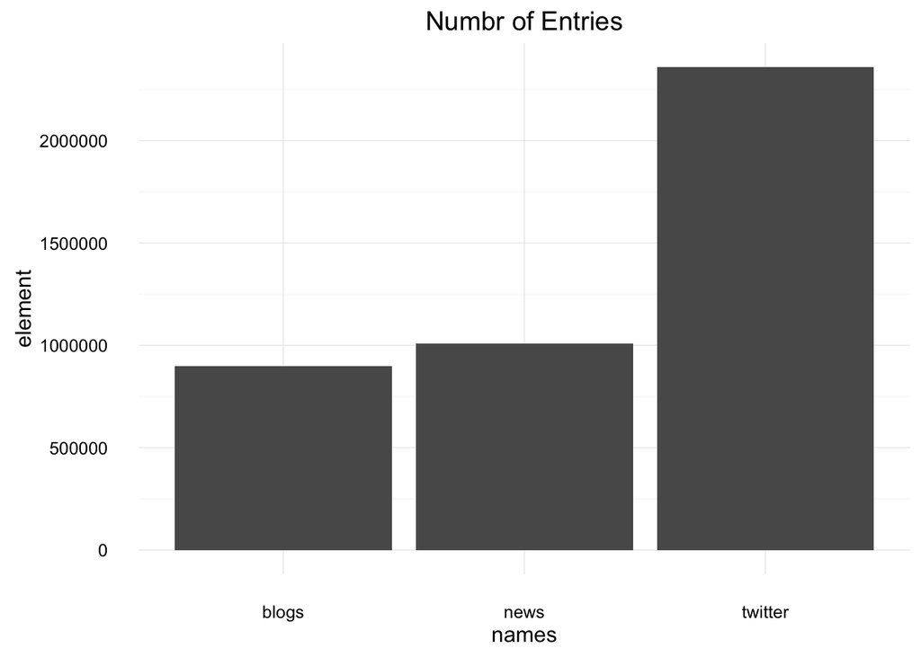

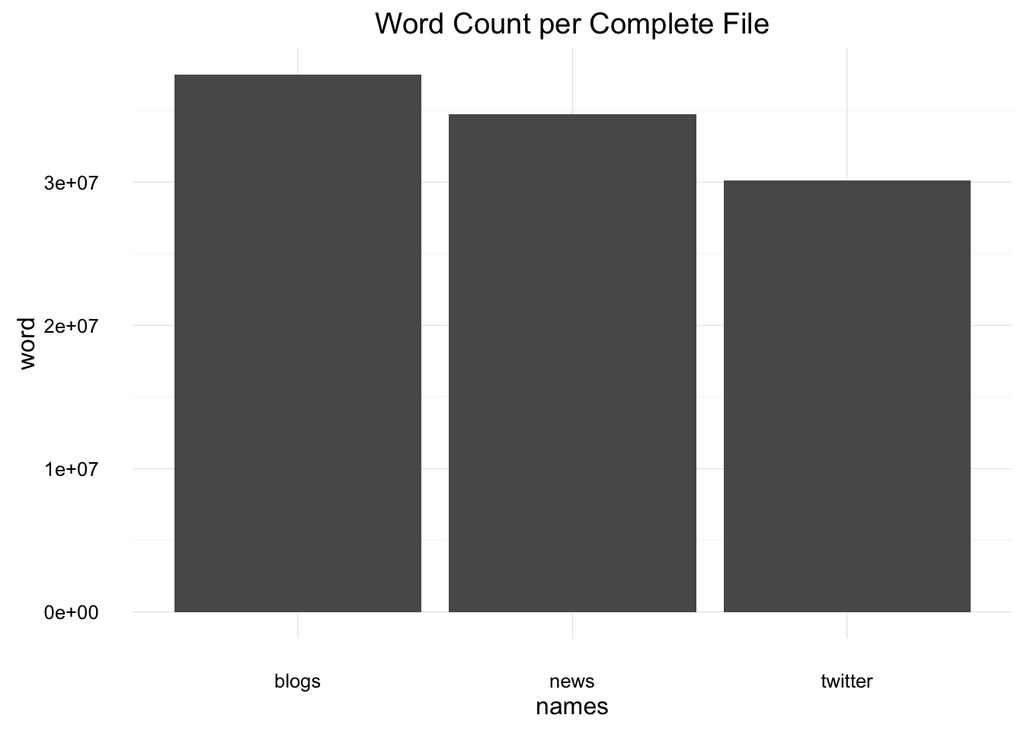

### Data Prep & Clean up

To make this easier I am going to work with a sample that is 1% of the total data set. I am going to sample from each file (blogs, news and twitter) and then combine the total set.

```r
set.seed(1)
sampledata <- c(sample(blogs, length(blogs) * .01),
                sample(news, length(news) * .01),
                sample(twitter, length(twitter) * .01))
```

Next I am going to build my corpus from the sample data. As you can see from the summary, I have 42695 documents in my corpus.

```r
Corpus <- corpus(sampledata)
summary(Corpus, n=10)
```

```
## Corpus consisting of 42695 documents, showing 10 documents.
##
##    Text Types Tokens Sentences
##   text1   109    172         6
##   text2     9     11         1
##   text3    48     68         4
##   text4     6      7         1
##   text5    26     29         3
##   text6    87    116         6
##   text7    13     15         2
##   text8    34     38         2
##   text9    43     54         2
##  text10    57     82         2
##
## Source:  /Users/dianeclow/Documents/Coursera/DataScience/Capstone-Project/* on x86_64 by dianeclow
## Created: Sun Nov 27 18:20:02 2016
## Notes:
```

### n-gram Work

I then use the dfm function to create a document-feature matrix. The dfm function includes a numner of useful automatic arguments: converts everything to lower case, removes punctuation, removes seperators, and removes twitter information. The topfeatures function shows the top 20 most common words.

```r
dfm <- dfm(Corpus)
```

```
## Creating a dfm from a corpus ...
```

```
##
##    ... lowercasing
```

```
##
##    ... tokenizing
```

```
##
##    ... indexing documents: 42,695 documents
```

```
##
##    ... indexing features:
```

```
## 58,158 feature types
```

```
##    ... created a 42695 x 58158 sparse dfm
##    ... complete.
## Elapsed time: 3.33 seconds.
```

```r
dfm
```

```
## Document-feature matrix of: 42,695 documents, 58,158 features.
```

```r
topfeatures(dfm, 20)
```

```
##   the    to   and     a    of    in     i   for    is  that   you    it
## 47554 27577 23986 23764 19804 16401 16392 10967 10759 10259  9369  9053
##    on  with   was    my    at    be  this  have
##  8103  7189  6121  6045  5796  5529  5491  5313
```

Next I created pair and triplet tokens. Using the same function as before I was able to change the ngram variable and run the same analysis.

```r
dfm.pair <- dfm(Corpus, ngrams = 2)
```

```
## Creating a dfm from a corpus ...
```

```
##
##    ... lowercasing
```

```
##
##    ... tokenizing
```

```
##
##    ... indexing documents: 42,695 documents
```

```
##
##    ... indexing features:
```

```
## 443,026 feature types
```

```
##    ... created a 42695 x 443026 sparse dfm
##    ... complete.
## Elapsed time: 11.6 seconds.
```

```r
dfm.triple <- dfm(Corpus, ngram = 3)
```

```
## Creating a dfm from a corpus ...
```

```
##
##    ... lowercasing
```

```
##
##    ... tokenizing
```

```
##
##    ... indexing documents: 42,695 documents
```

```
##
##    ... indexing features:
```

```
## 767,850 feature types
```

```
##    ... created a 42695 x 767850 sparse dfm
##    ... complete.
## Elapsed time: 10.7 seconds.
```

```r
dfm.pair
```

```
## Document-feature matrix of: 42,695 documents, 443,026 features.
```

```r
dfm.triple
```

```
## Document-feature matrix of: 42,695 documents, 767,850 features.
```

```r
topfeatures(dfm.pair, 20)
```

```
##   of_the   in_the   to_the  for_the   on_the    to_be   at_the  and_the
##     4249     4127     2225     1974     1958     1603     1426     1288
##     in_a with_the     is_a    for_a   it_was   i_have from_the  will_be
##     1166     1058     1009      949      907      884      882      881
##    it_is   with_a    i_was    and_i
##      862      853      852      851
```

```r
topfeatures(dfm.triple, 20)
```

```
##         one_of_the           a_lot_of     thanks_for_the
##                357                303                216
##        going_to_be            to_be_a         as_well_as
##                186                168                167
##         out_of_the        some_of_the         be_able_to
##                158                146                139
##          i_want_to           it_was_a         the_end_of
##                139                138                135
##        the_rest_of     the_first_time           i_have_a
##                130                125                123
##        part_of_the        is_going_to looking_forward_to
##                118                118                117
##        you_have_to          i_have_to
##                115                107
```

I also created some word clouds to visually be able to see what the common words and word pairs are.

The most common words that you notice in the single word cloud are (in no particular order): the, that, you, a, to, on, of, and, in, for, it, is, and i. These words are all different colors than the base green as well as being noticably larger, and if you check with the table above, you will see that I listed the top 13 words.

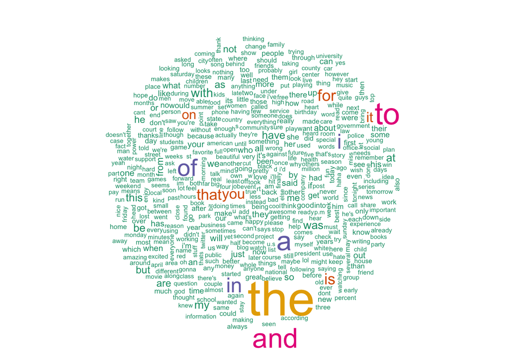

```r
plot(dfm, max.words = 500, colors = brewer.pal(6, "Dark2"))
```

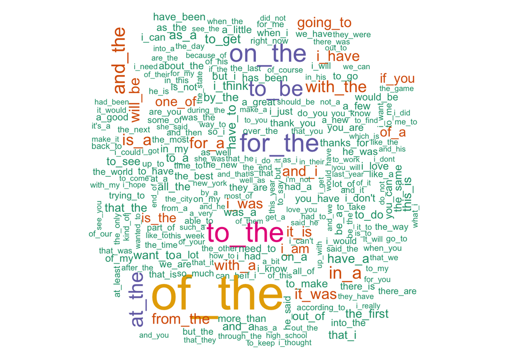

```r
plot(dfm.pair, max.words = 250, colors = brewer.pal(6, "Dark2"))
```

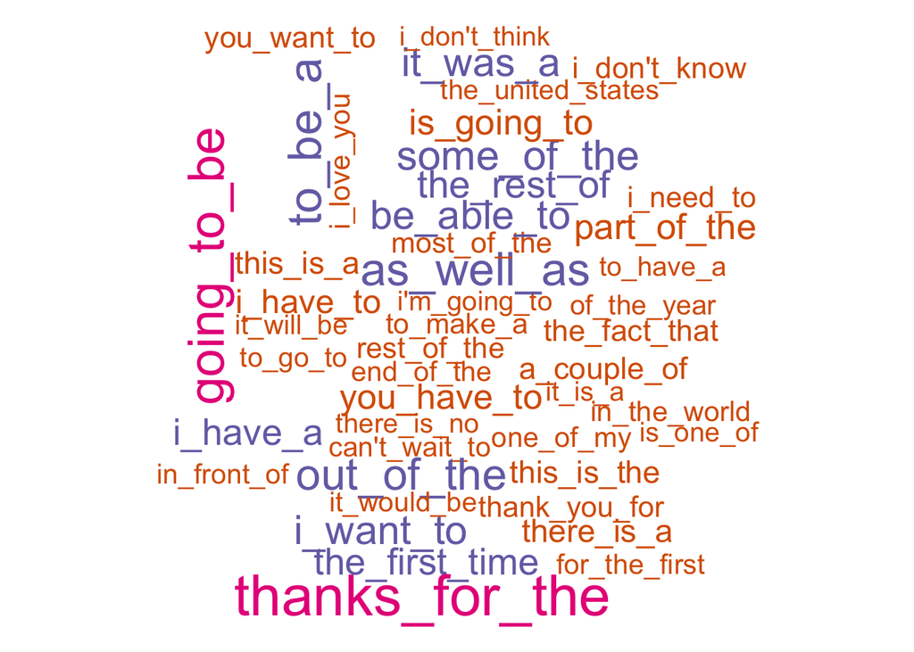

```r
plot(dfm.triple, max.words = 50, colors = brewer.pal(6, "Dark2"))
```

### Next Steps

At this point I feel like I need to keep looking for patterns before I start building my model. As I showed with the word cloud there is not a natural progression of clustering around the same words, and I would like to explore more with what is going on there.